# BGJX blogspot

## [Membuat Blog Menggunakan Pelican dan Tema Bootstrap3](https://bgjx.github.io/blogs/posts/2022/Mar/26/membuat-blog-menggunakan-pelican-dan-tema-bootstrap3)

#### **Membuat Environment Kerja Baru**

Sebelum menginstal Pelican ada baiknya membuat virtual environment pada area kerja anda untuk mencegah inner-conflict atau kerusakan pada global environment python yang sudah ada. Untuk itu digunakan tool [virtualenv](https://pypi.org/project/virtualenv/).

`virtualenv` dapat dengan mudah diinstal menggunakan [pip](https://pip.pypa.io/en/stable/).

```
pip install virtualenv
```

Kemudian untuk membuat virtual environment di area kerja anda gunakan command berikut ini:

```
virtualenv ~/myproject/project_pelican ##contoh area kerja anda
cd ~/myproject/project_pelican ##masuk ke area kerja
source bin/activate ##aktivasi area kerja
```

**NB:** pada artikel ini semua command dipanggil menggunakan terminal pada OS Linux, terdapat begitu banyak resource yang dapat anda pelajari secara mandiri tentang bagaimana menggunakan utilitas terminal pada OS Windows ataupun macOS (macOS relatife sama dengan Linux).

#### **Instal Pelican**

Lalu [instal Pelican](https://docs.getpelican.com/en/latest/install.html) menggunakan pip pada area kerja

`python -m pip install pelican`

untuk upgrade pelican

`python -m pip install --upgrade pelican`

#### **Pelican Quickstart**

Setelah Pelican terinstal pada area kerja yang diinginkan, saatnya memulai membangun blog anda.

`pelican-quickstart`

perintah ini akan memunculkan beberapa pertanyaan awal mengenai website yang akan ada bangun.

[more ...](https://bgjx.github.io/blogs/posts/2022/Mar/26/membuat-blog-menggunakan-pelican-dan-tema-bootstrap3)

## [Basic Python Data Processing and Visualization](https://bgjx.github.io/blogs/posts/2022/Mar/08/basic-python-data-processing-and-visualization)

### The Dataset of Ramens Ratings

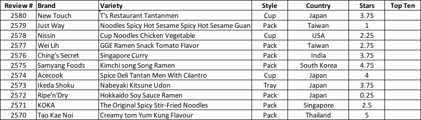

Each record in the dataset is a single ramen product review. Review numbers are contiguous: more recently reviewed ramen varieties have higher numbers. Brand, Variety (the product name), Country, and Style (Cup? Bowl? Tray?) are pretty self-explanatory. Stars indicate the ramen quality, as assessed by the reviewer, on a 5-point scale; this is the most important column in the dataset!

Source : https://www.kaggle.com/residentmario/ramen-ratings

[more ...](https://bgjx.github.io/blogs/posts/2022/Mar/08/basic-python-data-processing-and-visualization)